# WGCNA CR

WGCNA analysis of CR gene expression in B. rapa RILs. See separate notebook for UN gene expression.

Lets start with some notes on what WGCNA is doing. (For more details, see [Zhang and Horvath, 2005](http://www.degruyter.com/view/j/sagmb.2005.4.1/sagmb.2005.4.1.1128/sagmb.2005.4.1.1128.xml;jsessionid=9F14E37B32BBAEB8DD0286D168168E7F) )

1. A correlation coefficient is calculated between all gene pairs.
2. This is converted to an adjacency matrix. Unlike typical adjacency matrices (which have values of 0, meaning not connected, or 1, meaning connected, based on some hard threshold) here the adjacency matrix can take any value from 0 to 1. Thus there is a soft threshold and the connectivity in the adjacency matrix is weighted by the correlations. Zhang and Horvath discuss different ways to relate the correlation matrix to the adjacency matrix, the default in WGCNA, and what I use, is a power function where the adjacency represent the correlation coefficient raised to some power $\beta$.
3. The power, $\beta$, is chosen such that the (weighted) connectivity shows a power law topology i.e. R2 of log10(p(k)) ~ log10(k) is > 0.9
4. Once an adjacency matrix is calculated the the similarity of nodes in the matrix is calculated using a topological overlap matrix (TOM). See Zhang and Horvath, 2005, for details. But basically a two nodes have a high TOM if they are connected to each other and to a similar set of other nodes.
5. To define modules genes are hiearchicaly clustered based on their distance (1-TOM) and a dynamic method is used to define cutoffs from this tree and the dissimilarity matrix. For more info see [here](https://labs.genetics.ucla.edu/horvath/htdocs/CoexpressionNetwork/BranchCutting/)
6. I tshould be noted that Zhang and Horvath provide formula to generalize most network calcualtions (i.e. connectivity, etc) from a 0,1 adjacency matrix to a 0-1 adjacency matrix.

```r
library(tidyverse)
library(WGCNA)
library(ggplot2)
library(edgeR)
library(magrittr)
library(gplots)
library(stringr)
options(stringsAsFactors = FALSE)
```

Get data

```r
#box_load(162362592785)
load("~/Box Sync/BrapaNetworks/Voom_CR_UN.Rdata")
annotation  <- read.csv("~/Box Sync/BrapaNetworks/Brapa_V1.5_annotated.csv.gz")
```

```r
RIL.coefs.CR <- grep("RIL",colnames(coef(voom.fit.CR)))
RIL.pvals.CR <- topTable(voom.fit.CR,coef = RIL.coefs.CR,number = Inf)
sum(RIL.pvals.CR$adj.P.Val<0.01)
```

```
[1] 13903
```

```r
sum(RIL.pvals.CR$adj.P.Val<10e-05)
```

```
[1] 8162
```

Start by taking the top 10000

```r
genes.of.interest.CR <- row.names(RIL.pvals.CR)[1:10000]
expr.data.CR <- voom.fit.CR$coefficients[genes.of.interest.CR,]
dim(expr.data.CR)
```

```
[1] 10000   124
```

```r
head(expr.data.CR[,1:6])
```

```
          (Intercept) pdata.CR$RILRIL_103 pdata.CR$RILRIL_104 pdata.CR$RILRIL_113 pdata.CR$RILRIL_115
Bra016271  8.68333168           0.1309614          -6.5666021         -4.64724097          0.11402461
Bra035985  0.99705885           0.1727422           4.1021423         -0.02417053         -0.01133281
Bra022069 -0.08034204          -0.2134252           6.2346213          1.09944954         -0.65449185
Bra040221  5.64722026          -0.2288833          -3.8419920         -5.27077319         -5.78284163
Bra014438  3.71020663          -0.5362256           2.2519975          1.61149236          2.05457717
Bra032770  6.23045147          -7.2320385          -0.2095483         -5.20800675          0.31494052
          pdata.CR$RILRIL_12
Bra016271         -6.0827513
Bra035985          4.0109959
Bra022069          6.3305105
Bra040221          0.1159076
Bra014438         -5.8842582
Bra032770          0.4739283
```

```r
expr.data.CR[,-1] <- expr.data.CR[,-1] + expr.data.CR[,1] # add the intercept to the coefficients
colnames(expr.data.CR) <- sub("pdata.CR$RIL","",colnames(expr.data.CR),fixed=TRUE)
colnames(expr.data.CR)[1] <- "RIL_1"
head(expr.data.CR[,1:6])
```

```
                RIL_1    RIL_103  RIL_104   RIL_113    RIL_115    RIL_12
Bra016271  8.68333168  8.8142930 2.116730 4.0360907  8.7973563  2.600580
Bra035985  0.99705885  1.1698011 5.099201 0.9728883  0.9857260  5.008055
Bra022069 -0.08034204 -0.2937673 6.154279 1.0191075 -0.7348339  6.250168
Bra040221  5.64722026  5.4183369 1.805228 0.3764471 -0.1356214  5.763128
Bra014438  3.71020663  3.1739810 5.962204 5.3216990  5.7647838 -2.174052
Bra032770  6.23045147 -1.0015870 6.020903 1.0224447  6.5453920  6.704380
```

Get Rob’s Data

```r
blups2012 <- read.csv("~/Box Sync/BrapaNetworks/Brapa2012BayesHeight_blups.csv", row.names = 1)
blups2012$Line %<>% paste("RIL",.,sep="_")
blups2012 %<>% subset(select=!grepl("V1|individual|blk|trt|treat",colnames(.)))
head(blups2012)
```

|  | Line | UNr | CRr | UNHmax | CRHmax | UNInflection_DD | CRInflection_DD | UNInflection_size | CRInflection_size | UNduration | CRduration | UNSTP | CRSTP |
| --- | --- | --- | --- | --- | --- | --- | --- | --- | --- | --- | --- | --- | --- |
| 1 | RIL_1 | 0.01265305 | 0.01294648 | 40.07475 | 35.68622 | 659.1968 | 616.8299 | 20.037377 | 17.843108 | 944.3922 | 887.0163 | 38.41570 | 34.27094 |
| 2 | RIL_2 | 0.01312970 | 0.01320636 | 49.99002 | 45.20347 | 661.9006 | 635.2602 | 24.995008 | 22.601736 | 917.1550 | 895.7425 | 48.01279 | 43.13936 |
| 3 | RIL_7 | 0.01368674 | 0.01445970 | 37.62779 | 33.04620 | 516.3685 | 494.4886 | 18.813894 | 16.523101 | 761.0105 | 750.1993 | 35.74825 | 31.68395 |
| 4 | RIL_9 | 0.01339133 | 0.01469806 | 29.83789 | 24.81520 | 545.0483 | 497.9265 | 14.918945 | 12.407598 | 800.6085 | 721.0262 | 28.78392 | 23.71262 |
| 5 | RIL_12 | 0.01447632 | 0.01550266 | 19.86868 | 19.65954 | 516.6281 | 492.9761 | 9.934341 | 9.829771 | 762.5616 | 727.8776 | 18.79155 | 18.73104 |
| 6 | RIL_15 | 0.01324382 | 0.01385887 | 47.85415 | 42.64318 | 616.4516 | 596.4780 | 23.927076 | 21.321591 | 876.2526 | 853.8673 | 46.63094 | 40.88605 |

```r
blups.CR <- blups2012 %>% select(starts_with("Line"),starts_with("CR"),-matches("Inflection_size"))
head(blups.CR)
```

|  | Line | CRr | CRHmax | CRInflection_DD | CRduration | CRSTP |
| --- | --- | --- | --- | --- | --- | --- |
| 1 | RIL_1 | 0.01294648 | 35.68622 | 616.8299 | 887.0163 | 34.27094 |
| 2 | RIL_2 | 0.01320636 | 45.20347 | 635.2602 | 895.7425 | 43.13936 |
| 3 | RIL_7 | 0.01445970 | 33.04620 | 494.4886 | 750.1993 | 31.68395 |
| 4 | RIL_9 | 0.01469806 | 24.81520 | 497.9265 | 721.0262 | 23.71262 |
| 5 | RIL_12 | 0.01550266 | 19.65954 | 492.9761 | 727.8776 | 18.73104 |
| 6 | RIL_15 | 0.01385887 | 42.64318 | 596.4780 | 853.8673 | 40.88605 |

## WGCNA

### CR

transform

```r
head(expr.data.CR[,1:6])
```

```
                RIL_1    RIL_103  RIL_104   RIL_113    RIL_115    RIL_12
Bra016271  8.68333168  8.8142930 2.116730 4.0360907  8.7973563  2.600580
Bra035985  0.99705885  1.1698011 5.099201 0.9728883  0.9857260  5.008055
Bra022069 -0.08034204 -0.2937673 6.154279 1.0191075 -0.7348339  6.250168
Bra040221  5.64722026  5.4183369 1.805228 0.3764471 -0.1356214  5.763128
Bra014438  3.71020663  3.1739810 5.962204 5.3216990  5.7647838 -2.174052
Bra032770  6.23045147 -1.0015870 6.020903 1.0224447  6.5453920  6.704380
```

```r
expr.data.CR.t <- t(expr.data.CR)
head(expr.data.CR.t[,1:6])
```

```
        Bra016271 Bra035985   Bra022069  Bra040221 Bra014438 Bra032770
RIL_1    8.683332 0.9970589 -0.08034204  5.6472203  3.710207  6.230451
RIL_103  8.814293 1.1698011 -0.29376729  5.4183369  3.173981 -1.001587
RIL_104  2.116730 5.0992011  6.15427928  1.8052283  5.962204  6.020903
RIL_113  4.036091 0.9728883  1.01910749  0.3764471  5.321699  1.022445
RIL_115  8.797356 0.9857260 -0.73483390 -0.1356214  5.764784  6.545392
RIL_12   2.600580 5.0080547  6.25016848  5.7631278 -2.174052  6.704380
```

check sample quality

```r
gag.CR <- goodSamplesGenes(expr.data.CR.t, verbose = 3)
```

```
 Flagging genes and samples with too many missing values...
  ..step 1
```

```r
gag.CR$allOK
```

```
[1] TRUE
```

cluster samples to look for outliers

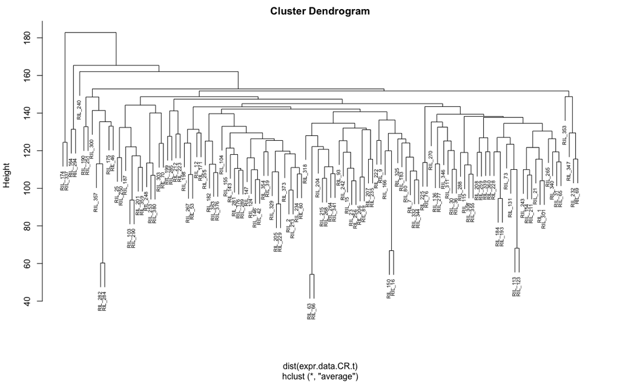

```r
sampleTREE.CR <- hclust(dist(expr.data.CR.t), method = "average")
plot(sampleTREE.CR,cex=.6)
```

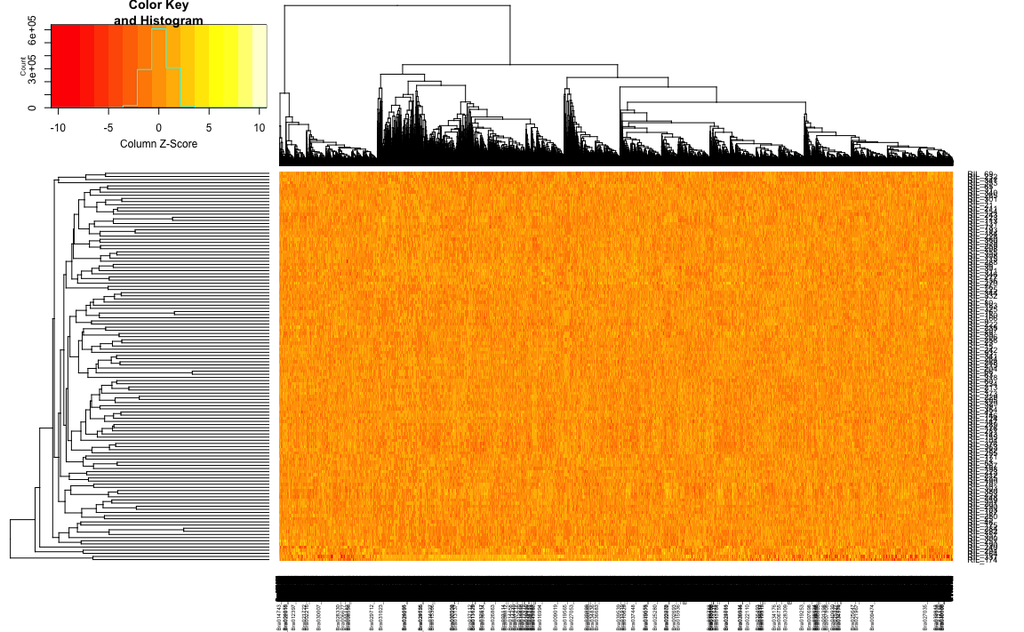

```r
heatmap.2(expr.data.CR.t,Rowv=as.dendrogram(sampleTREE.CR), scale="col", trace="none")
```

So a few samples are different but they don’t seem crazy different; leave them in for now.

Soft thresholding

```r
powers <- c(c(1:11), seq(from = 12, to=20, by=2))
sft <- pickSoftThreshold(expr.data.CR.t, powerVector = powers, verbose = 5, networkType = "signed hybrid", moreNetworkConcepts = TRUE)
```

```
pickSoftThreshold: will use block size 4473.
 pickSoftThreshold: calculating connectivity for given powers...
   ..working on genes 1 through 4473 of 10000
```

```
executing %dopar% sequentially: no parallel backend registered
```

```
   ..working on genes 4474 through 8946 of 10000
   ..working on genes 8947 through 10000 of 10000
   Power SFT.R.sq  slope truncated.R.sq mean.k. median.k. max.k.  Density Centralization Heterogeneity
1      1    0.113 -0.966          0.933 794.000  759.0000 1520.0 7.94e-02        0.07220         0.281
2      2    0.540 -1.670          0.929 214.000  186.0000  634.0 2.14e-02        0.04200         0.507
3      3    0.798 -1.840          0.973  78.200   60.9000  326.0 7.82e-03        0.02480         0.708
4      4    0.877 -1.960          0.988  34.800   24.3000  199.0 3.48e-03        0.01640         0.892
5      5    0.898 -2.050          0.991  17.800   11.0000  135.0 1.78e-03        0.01170         1.070
6      6    0.912 -2.060          0.993  10.100    5.5200   96.7 1.01e-03        0.00866         1.240
7      7    0.918 -2.010          0.990   6.230    2.9900   71.9 6.23e-04        0.00657         1.410
8      8    0.924 -1.930          0.987   4.080    1.7000   55.0 4.08e-04        0.00509         1.580
9      9    0.935 -1.830          0.985   2.810    0.9930   43.0 2.81e-04        0.00402         1.750
10    10    0.951 -1.730          0.985   2.010    0.6060   34.1 2.01e-04        0.00321         1.920
11    11    0.965 -1.630          0.983   1.490    0.3760   27.5 1.49e-04        0.00260         2.090
12    12    0.973 -1.580          0.987   1.140    0.2410   23.4 1.14e-04        0.00223         2.260
13    14    0.955 -1.570          0.977   0.713    0.1030   18.7 7.13e-05        0.00180         2.590
14    16    0.932 -1.610          0.972   0.479    0.0468   16.3 4.80e-05        0.00158         2.900
15    18    0.939 -1.590          0.983   0.341    0.0218   14.4 3.41e-05        0.00140         3.210
16    20    0.949 -1.560          0.986   0.253    0.0106   12.8 2.53e-05        0.00126         3.520
```

```r
sizeGrWindow(9, 5)
par(mfrow = c(1,2))
cex1 <- 0.9
# Scale-free topology fit index as a fCRction of the soft-thresholding power
plot(sft$fitIndices[,1], -sign(sft$fitIndices[,3])*sft$fitIndices[,2],
     xlab="Soft Threshold (power)",ylab="Scale Free Topology Model Fit,signed R^2",type="n",
     main = paste("Scale independence"))
text(sft$fitIndices[,1], -sign(sft$fitIndices[,3])*sft$fitIndices[,2],
     labels=powers,cex=cex1,col="red")
```

```r
# this line corresponds to using an R^2 cut-off of h
abline(h=0.90,col="red")
# Mean connectivity as a fCRction of the soft-thresholding power
plot(sft$fitIndices[,1], sft$fitIndices[,5],
     xlab="Soft Threshold (power)",ylab="Mean Connectivity", type="n",
     main = paste("Mean connectivity"))
```

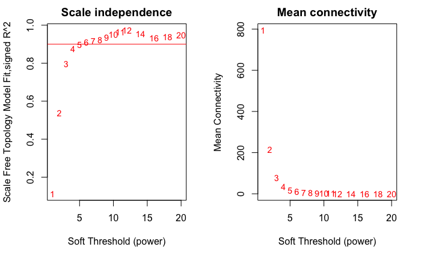

```r
text(sft$fitIndices[,1], sft$fitIndices[,5], labels=powers, cex=cex1,col="red")
```

choose 7. This gives the best correlations with growth parameters

```r
softPower <- 7
adjacency <- adjacency(expr.data.CR.t, power = softPower, type= "signed hybrid")
# Turn adjacency into topological overlap
TOM <- TOMsimilarity(adjacency);
```

```
..connectivity..
..matrix multiplication..
..normalization..
..done.
```

```r
dissTOM <- 1-TOM
```

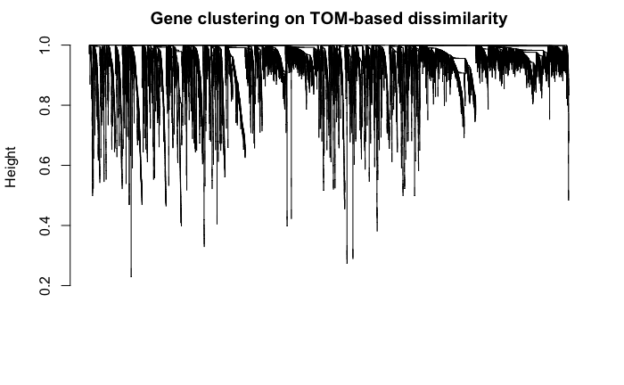

```r
# Call the hierarchical clustering fCRction
geneTree <- hclust(as.dist(dissTOM), method = "average")
# Plot the resulting clustering tree (dendrogram)
sizeGrWindow(12,9)
plot(geneTree, xlab="", sub="", main = "Gene clustering on TOM-based dissimilarity",
     labels = FALSE, hang = 0.04)
```

define modules

```r
# We like large modules, so we set the minimum module size relatively high:
minModuleSize <- 30;
# Module identification using dynamic tree cut:
dynamicMods <- cutreeDynamic(dendro = geneTree, distM = dissTOM,
                             deepSplit <- 2, pamRespectsDendro = FALSE,
                             minClusterSize = minModuleSize);
```

```
 ..done.
```

```r
table(dynamicMods)
```

```
dynamicMods
   1    2    3    4    5    6    7    8    9   10   11   12   13   14   15   16   17   18   19   20   21   22   23   24
1302 1232  821  668  554  548  329  292  219  198  194  173  165  163  154  150  148  144  129  129  121  115  107  104
  25   26   27   28   29   30   31   32   33   34   35   36   37   38   39   40   41   42   43   44   45   46   47   48
  98   95   91   84   83   81   81   77   76   73   73   71   70   69   69   68   65   63   62   58   55   52   46   46
  49   50   51
  46   46   43
```

```r
# Convert numeric lables into colors
dynamicColors = labels2colors(dynamicMods)
table(dynamicColors)
```

```
dynamicColors
        bisque4           black            blue           brown          brown4            cyan       darkgreen
             46             329            1232             821              52             163             115
       darkgrey     darkmagenta  darkolivegreen      darkorange     darkorange2         darkred   darkslateblue
            104              73              76              95              55             121              46
  darkturquoise     floralwhite           green     greenyellow          grey60           ivory       lightcyan
            107              58             554             194             148              62             150
     lightcyan1      lightgreen lightsteelblue1     lightyellow         magenta   mediumpurple3    midnightblue
             63             144              65             129             219              68             154
         orange      orangered4   paleturquoise            pink           plum1           plum2          purple
             98              69              81             292              69              46             198
            red       royalblue     saddlebrown          salmon         sienna3         skyblue        skyblue3
            548             129              83             165              73              84              70
      steelblue             tan        thistle1        thistle2       turquoise          violet           white
             81             173              43              46            1302              77              91
         yellow     yellowgreen
            668              71
```

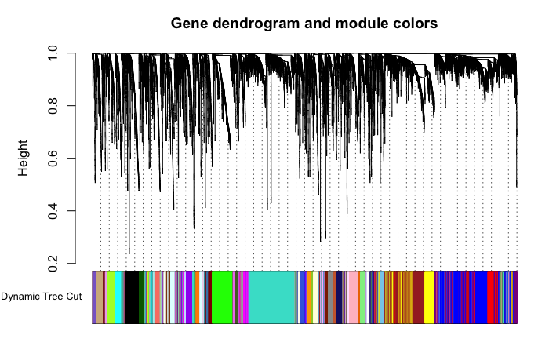

```r
# Plot the dendrogram and colors CRderneath
sizeGrWindow(8,6)
plotDendroAndColors(geneTree, dynamicColors, "Dynamic Tree Cut",
                    dendroLabels = FALSE, hang = 0.03,
                    addGuide = TRUE, guideHang = 0.05,
                    main = "Gene dendrogram and module colors")
```

merge similar modules

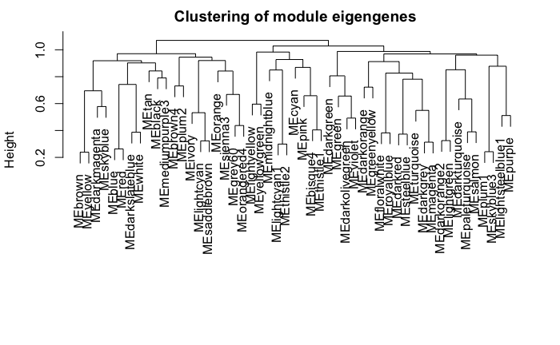

```r
# Calculate eigengenes
MEList <- moduleEigengenes(expr.data.CR.t, colors = dynamicColors)
MEs <- MEList$eigengenes
# Calculate dissimilarity of module eigengenes
MEDiss <- 1-cor(MEs);
# Cluster module eigengenes
METree <- hclust(as.dist(MEDiss), method = "average");
# Plot the result
sizeGrWindow(7, 6)
plot(METree, main = "Clustering of module eigengenes",
     xlab = "", sub = "")
```

merge with correlation > 0.8

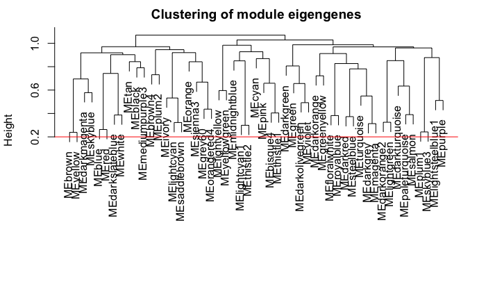

```r
MEDissThres = 0.2
# Plot the cut line into the dendrogram
plot(METree, main = "Clustering of module eigengenes",
     xlab = "", sub = "")
abline(h=MEDissThres, col = "red")
```

```r
# Call an automatic merging fCRction
merge = mergeCloseModules(expr.data.CR.t, dynamicColors, cutHeight = MEDissThres, verbose = 3)
```

```
 mergeCloseModules: Merging modules whose distance is less than 0.2
   multiSetMEs: Calculating module MEs.
     Working on set 1 ...
     moduleEigengenes: Calculating 51 module eigengenes in given set.
   Calculating new MEs...
   multiSetMEs: Calculating module MEs.
     Working on set 1 ...
     moduleEigengenes: Calculating 51 module eigengenes in given set.
```

```r
# The merged module colors
mergedColors = merge$colors
# Eigengenes of the new merged modules:
mergedMEs = merge$newMEs
table(merge$colors)
```

```
        bisque4           black            blue           brown          brown4            cyan       darkgreen
             46             329            1232             821              52             163             115
       darkgrey     darkmagenta  darkolivegreen      darkorange     darkorange2         darkred   darkslateblue
            104              73              76              95              55             121              46
  darkturquoise     floralwhite           green     greenyellow          grey60           ivory       lightcyan
            107              58             554             194             148              62             150
     lightcyan1      lightgreen lightsteelblue1     lightyellow         magenta   mediumpurple3    midnightblue
             63             144              65             129             219              68             154
         orange      orangered4   paleturquoise            pink           plum1           plum2          purple
             98              69              81             292              69              46             198
            red       royalblue     saddlebrown          salmon         sienna3         skyblue        skyblue3
            548             129              83             165              73              84              70
      steelblue             tan        thistle1        thistle2       turquoise          violet           white
             81             173              43              46            1302              77              91
         yellow     yellowgreen
            668              71
```

```r
length(table(merge$colors))
```

```
[1] 51
```

```r
median(table(merge$colors))
```

```
darkorange
        95
```

compare pre and post merge

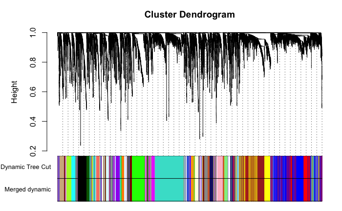

```r
sizeGrWindow(12, 9)
#pdf(file = "Plots/geneDendro-3.pdf", wi = 9, he = 6)
plotDendroAndColors(geneTree, cbind(dynamicColors, mergedColors),
c("Dynamic Tree Cut", "Merged dynamic"),
dendroLabels = FALSE, hang = 0.03,
addGuide = TRUE, guideHang = 0.05)
```

```r
#dev.off()
```

```r
# Rename to moduleColors
moduleColors = mergedColors
# Construct numerical labels corresponding to the colors
colorOrder = c("grey", standardColors(50));
moduleLabels = match(moduleColors, colorOrder)-1;
MEs = mergedMEs
```

```r
head(MEs)
```

|  | MEbrown | MEyellow | MEdarkmagenta | MEskyblue | MEblue | MEred | MEdarkslateblue | MEwhite | MEtan | MEblack | MEmediumpurple3 | MEbrown4 | MEplum2 | MEivory | MElightcyan | MEsaddlebrown | MEorange | MEsienna3 | MEgrey60 | MEorangered4 | MElightyellow | MEyellowgreen | MEmidnightblue | MElightcyan1 | MEthistle2 | MEcyan | MEpink | MEbisque4 | MEthistle1 | … |
| --- | --- | --- | --- | --- | --- | --- | --- | --- | --- | --- | --- | --- | --- | --- | --- | --- | --- | --- | --- | --- | --- | --- | --- | --- | --- | --- | --- | --- | --- | --- |
| 1 | -0.03389661 | -0.01944675 | 0.006643409 | -0.01644221 | -0.027783077 | -0.039537855 | -0.10109769 | -0.04645855 | 0.11714045 | -0.10400910 | 0.02261471 | 0.11318581 | 0.06557221 | -0.07772640 | -0.08169263 | -0.0928787260 | 0.09771943 | -0.02532717 | 0.03231181 | -0.13050582 | -0.0921387 | 0.03937373 | -0.11098021 | 0.10022108 | 0.11163787 | -0.09753118 | -0.11545365 | -0.09188614 | -0.10506090 | … |
| 2 | 0.07759605 | 0.09887966 | -0.051257770 | 0.02368452 | -0.085099698 | -0.037936095 | 0.06629268 | 0.06071255 | -0.03922266 | -0.13509259 | 0.01759411 | -0.10377314 | 0.09642765 | 0.09741171 | 0.08702771 | 0.0896612382 | 0.09562789 | 0.08357304 | 0.06451942 | 0.08558860 | -0.1004586 | 0.07660923 | 0.02937422 | -0.08399298 | -0.01358563 | -0.10318236 | -0.13099130 | -0.11599030 | -0.09184553 | … |
| 3 | -0.13357331 | -0.12628288 | -0.047493508 | -0.09942304 | -0.058498921 | -0.158854935 | 0.07191748 | -0.02762441 | 0.11928784 | 0.06260149 | 0.04952254 | 0.14997070 | 0.10712544 | 0.11049417 | -0.06280761 | -0.0670094531 | -0.08139301 | 0.08867316 | 0.07331520 | 0.10518384 | -0.0877949 | 0.10214225 | -0.10775719 | -0.06454022 | -0.07012184 | -0.03857073 | 0.05361432 | -0.10215509 | -0.11364907 | … |
| 4 | 0.24030668 | 0.15343232 | 0.145038248 | 0.10412079 | 0.001760807 | 0.059246683 | -0.09241177 | -0.09557557 | -0.06715356 | -0.09981339 | 0.02754877 | -0.05324383 | -0.07001704 | -0.08237664 | -0.07043486 | -0.0894566320 | -0.06528603 | -0.09730423 | -0.10560594 | 0.02007865 | 0.1050335 | 0.04065292 | 0.07407185 | 0.12010407 | 0.12694237 | -0.02199442 | 0.09342621 | 0.09352582 | 0.08785211 | … |
| 5 | -0.11132763 | -0.14113288 | -0.095064037 | -0.10265786 | 0.165445927 | 0.006574383 | 0.06122868 | 0.08336585 | 0.10282105 | -0.09915645 | 0.03116606 | 0.11332689 | -0.07834707 | -0.07141372 | -0.09042300 | 0.0009702292 | 0.09581114 | -0.12752993 | -0.13705374 | -0.06141031 | -0.1055029 | 0.07208750 | -0.03892376 | -0.10101501 | -0.09427569 | 0.07461388 | 0.10507471 | 0.08831361 | 0.10688103 | … |
| 6 | -0.08003563 | -0.04563502 | -0.083131214 | -0.08111746 | 0.215514295 | 0.130423628 | 0.05058972 | 0.10879039 | 0.13819622 | 0.09941981 | 0.04471345 | -0.10926178 | -0.08553624 | 0.10753130 | -0.07029191 | -0.0884848695 | -0.12203201 | -0.12097020 | -0.13105851 | -0.11937780 | -0.0604300 | 0.08353096 | 0.07965483 | -0.09338577 | -0.07779965 | 0.10960256 | -0.07995235 | -0.10837151 | -0.02126260 | … |

```r
dim(MEs)
```

```
[1] 124  51
```

```r
dim(blups.CR)
```

```
[1] 121   6
```

```r
rownames(expr.data.CR.t)
```

```
  [1] "RIL_1"   "RIL_103" "RIL_104" "RIL_113" "RIL_115" "RIL_12"  "RIL_123" "RIL_124" "RIL_131" "RIL_136" "RIL_143"
 [12] "RIL_146" "RIL_147" "RIL_15"  "RIL_150" "RIL_154" "RIL_155" "RIL_16"  "RIL_164" "RIL_166" "RIL_171" "RIL_174"
 [23] "RIL_175" "RIL_176" "RIL_182" "RIL_183" "RIL_184" "RIL_187" "RIL_190" "RIL_193" "RIL_198" "RIL_199" "RIL_2"
 [34] "RIL_201" "RIL_204" "RIL_205" "RIL_206" "RIL_207" "RIL_208" "RIL_21"  "RIL_211" "RIL_212" "RIL_213" "RIL_215"
 [45] "RIL_222" "RIL_223" "RIL_225" "RIL_228" "RIL_229" "RIL_23"  "RIL_232" "RIL_234" "RIL_235" "RIL_240" "RIL_242"
 [56] "RIL_243" "RIL_248" "RIL_25"  "RIL_250" "RIL_251" "RIL_253" "RIL_255" "RIL_256" "RIL_259" "RIL_264" "RIL_265"
 [67] "RIL_267" "RIL_268" "RIL_270" "RIL_277" "RIL_281" "RIL_282" "RIL_284" "RIL_285" "RIL_288" "RIL_289" "RIL_290"
 [78] "RIL_294" "RIL_30"  "RIL_300" "RIL_301" "RIL_303" "RIL_308" "RIL_31"  "RIL_311" "RIL_318" "RIL_325" "RIL_329"
 [89] "RIL_332" "RIL_337" "RIL_339" "RIL_340" "RIL_341" "RIL_344" "RIL_346" "RIL_347" "RIL_353" "RIL_354" "RIL_355"
[100] "RIL_357" "RIL_359" "RIL_36"  "RIL_360" "RIL_363" "RIL_373" "RIL_376" "RIL_380" "RIL_39"  "RIL_42"  "RIL_46"
[111] "RIL_53"  "RIL_60"  "RIL_63"  "RIL_65"  "RIL_66"  "RIL_69"  "RIL_7"   "RIL_70"  "RIL_73"  "RIL_76"  "RIL_80"
[122] "RIL_89"  "RIL_9"   "RIL_93"
```

```r
rownames(MEs)
```

```
  [1] "1"   "2"   "3"   "4"   "5"   "6"   "7"   "8"   "9"   "10"  "11"  "12"  "13"  "14"  "15"  "16"  "17"  "18"  "19"
 [20] "20"  "21"  "22"  "23"  "24"  "25"  "26"  "27"  "28"  "29"  "30"  "31"  "32"  "33"  "34"  "35"  "36"  "37"  "38"
 [39] "39"  "40"  "41"  "42"  "43"  "44"  "45"  "46"  "47"  "48"  "49"  "50"  "51"  "52"  "53"  "54"  "55"  "56"  "57"
 [58] "58"  "59"  "60"  "61"  "62"  "63"  "64"  "65"  "66"  "67"  "68"  "69"  "70"  "71"  "72"  "73"  "74"  "75"  "76"
 [77] "77"  "78"  "79"  "80"  "81"  "82"  "83"  "84"  "85"  "86"  "87"  "88"  "89"  "90"  "91"  "92"  "93"  "94"  "95"
 [96] "96"  "97"  "98"  "99"  "100" "101" "102" "103" "104" "105" "106" "107" "108" "109" "110" "111" "112" "113" "114"
[115] "115" "116" "117" "118" "119" "120" "121" "122" "123" "124"
```

```r
rownames(MEs) <- rownames(expr.data.CR.t)
head(blups.CR)
```

|  | Line | CRr | CRHmax | CRInflection_DD | CRduration | CRSTP |
| --- | --- | --- | --- | --- | --- | --- |
| 1 | RIL_1 | 0.01294648 | 35.68622 | 616.8299 | 887.0163 | 34.27094 |
| 2 | RIL_2 | 0.01320636 | 45.20347 | 635.2602 | 895.7425 | 43.13936 |
| 3 | RIL_7 | 0.01445970 | 33.04620 | 494.4886 | 750.1993 | 31.68395 |
| 4 | RIL_9 | 0.01469806 | 24.81520 | 497.9265 | 721.0262 | 23.71262 |
| 5 | RIL_12 | 0.01550266 | 19.65954 | 492.9761 | 727.8776 | 18.73104 |
| 6 | RIL_15 | 0.01385887 | 42.64318 | 596.4780 | 853.8673 | 40.88605 |

```r
ME.blups <- merge(blups.CR,MEs,by.x=1.,by.y=0)
head(ME.blups)
```

|  | Line | CRr | CRHmax | CRInflection_DD | CRduration | CRSTP | MEbrown | MEyellow | MEdarkmagenta | MEskyblue | MEblue | MEred | MEdarkslateblue | MEwhite | MEtan | MEblack | MEmediumpurple3 | MEbrown4 | MEplum2 | MEivory | MElightcyan | MEsaddlebrown | MEorange | MEsienna3 | MEgrey60 | MEorangered4 | MElightyellow | MEyellowgreen | MEmidnightblue | … |
| --- | --- | --- | --- | --- | --- | --- | --- | --- | --- | --- | --- | --- | --- | --- | --- | --- | --- | --- | --- | --- | --- | --- | --- | --- | --- | --- | --- | --- | --- | --- |
| 1 | RIL_1 | 0.01294648 | 35.68622 | 616.8299 | 887.0163 | 34.27094 | -0.03389661 | -0.01944675 | 0.006643409 | -0.01644221 | -0.02778308 | -0.039537855 | -0.10109769 | -0.04645855 | 0.11714045 | -0.10400910 | 0.02261471 | 0.11318581 | 0.06557221 | -0.07772640 | -0.08169263 | -0.0928787260 | 0.09771943 | -0.02532717 | 0.03231181 | -0.13050582 | -0.09213870 | 0.03937373 | -0.11098021 | … |
| 2 | RIL_103 | 0.01425524 | 42.58231 | 581.7151 | 826.9314 | 40.99773 | 0.07759605 | 0.09887966 | -0.051257770 | 0.02368452 | -0.08509970 | -0.037936095 | 0.06629268 | 0.06071255 | -0.03922266 | -0.13509259 | 0.01759411 | -0.10377314 | 0.09642765 | 0.09741171 | 0.08702771 | 0.0896612382 | 0.09562789 | 0.08357304 | 0.06451942 | 0.08558860 | -0.10045864 | 0.07660923 | 0.02937422 | … |
| 3 | RIL_115 | 0.01394127 | 21.80572 | 629.6622 | 888.8281 | 20.72412 | -0.11132763 | -0.14113288 | -0.095064037 | -0.10265786 | 0.16544593 | 0.006574383 | 0.06122868 | 0.08336585 | 0.10282105 | -0.09915645 | 0.03116606 | 0.11332689 | -0.07834707 | -0.07141372 | -0.09042300 | 0.0009702292 | 0.09581114 | -0.12752993 | -0.13705374 | -0.06141031 | -0.10550294 | 0.07208750 | -0.03892376 | … |
| 4 | RIL_12 | 0.01550266 | 19.65954 | 492.9761 | 727.8776 | 18.73104 | -0.08003563 | -0.04563502 | -0.083131214 | -0.08111746 | 0.21551430 | 0.130423628 | 0.05058972 | 0.10879039 | 0.13819622 | 0.09941981 | 0.04471345 | -0.10926178 | -0.08553624 | 0.10753130 | -0.07029191 | -0.0884848695 | -0.12203201 | -0.12097020 | -0.13105851 | -0.11937780 | -0.06043000 | 0.08353096 | 0.07965483 | … |
| 5 | RIL_124 | 0.01241078 | 42.15245 | 720.1456 | 992.3727 | 39.94276 | -0.09444146 | -0.07564862 | 0.046012615 | 0.10783123 | -0.04943810 | -0.075809285 | -0.09731160 | -0.10131833 | 0.06712062 | 0.06647342 | 0.02578490 | -0.05807349 | 0.04525046 | 0.10705929 | 0.10279217 | 0.1160819109 | -0.09174526 | -0.09093735 | 0.05208547 | 0.10540365 | -0.05536902 | 0.12408329 | -0.01645523 | … |
| 6 | RIL_131 | 0.01342325 | 23.18828 | 490.7085 | 750.4677 | 22.06499 | 0.12580173 | 0.06548318 | 0.117049214 | 0.09495806 | -0.01729831 | 0.086587285 | -0.10687358 | -0.12640185 | -0.07051994 | -0.12584880 | 0.01301494 | 0.07703688 | -0.09384850 | -0.09583060 | -0.07610301 | -0.1116888344 | 0.01716187 | 0.08349847 | 0.06806270 | -0.06818521 | 0.07678105 | -0.11664073 | 0.01718386 | … |

```r
blups.cor <- cor(ME.blups[,2:6],ME.blups[,7:ncol(ME.blups)])
```

```r
blups.cor.P <- corPvalueStudent(blups.cor,nrow(expr.data.CR.t)) %>%
  p.adjust() %>% #using "holm" method.  For relaxed stringency could use "fdr"
  matrix(nrow=nrow(blups.cor),
         dimnames = dimnames(blups.cor))
sum(blups.cor.P < 0.05)
```

```
[1] 47
```

```r
blups.cor.sig <- blups.cor
blups.cor.sig[blups.cor.P>0.05] <- NA
blups.cor.sig
```

```
                   MEbrown   MEyellow MEdarkmagenta MEskyblue     MEblue      MEred MEdarkslateblue   MEwhite MEtan
CRr                     NA         NA     0.4458710        NA  0.3504001  0.4728517              NA 0.3819074    NA
CRHmax          -0.4519205         NA    -0.4036917        NA -0.4810702 -0.5784690              NA        NA    NA
CRInflection_DD -0.5698944 -0.4100675    -0.5189581        NA -0.3570811 -0.6001180              NA        NA    NA
CRduration      -0.5465083 -0.3868087    -0.5415883        NA -0.3893492 -0.6194047              NA        NA    NA
CRSTP           -0.4447783         NA    -0.4029703        NA -0.4798091 -0.5721882              NA        NA    NA
                MEblack MEmediumpurple3 MEbrown4 MEplum2 MEivory MElightcyan MEsaddlebrown MEorange MEsienna3 MEgrey60
CRr                  NA              NA       NA      NA      NA          NA            NA       NA        NA       NA
CRHmax               NA              NA       NA      NA      NA          NA            NA       NA        NA       NA
CRInflection_DD      NA              NA       NA      NA      NA          NA            NA       NA        NA       NA
CRduration           NA              NA       NA      NA      NA          NA            NA       NA        NA       NA
CRSTP                NA              NA       NA      NA      NA          NA            NA       NA        NA       NA
                MEorangered4 MElightyellow MEyellowgreen MEmidnightblue MElightcyan1 MEthistle2 MEcyan MEpink MEbisque4
CRr                       NA            NA            NA             NA   -0.3761121         NA     NA     NA        NA
CRHmax                    NA            NA            NA             NA           NA         NA     NA     NA        NA
CRInflection_DD           NA            NA            NA             NA           NA  0.3279441     NA     NA        NA
CRduration                NA            NA            NA             NA    0.3346586  0.3277641     NA     NA        NA
CRSTP                     NA            NA            NA             NA           NA         NA     NA     NA        NA
                MEthistle1 MEdarkgreen MEgreen MEdarkolivegreen   MEviolet MEdarkorange MEgreenyellow MEfloralwhite
CRr                     NA          NA      NA               NA -0.4577538           NA            NA            NA
CRHmax                  NA          NA      NA               NA  0.3460107           NA            NA            NA
CRInflection_DD         NA          NA      NA               NA         NA           NA            NA            NA
CRduration              NA          NA      NA               NA  0.3537828           NA            NA            NA
CRSTP                   NA          NA      NA               NA  0.3399486           NA            NA            NA
                MEroyalblue MEdarkred MEsteelblue MEturquoise MEdarkgrey  MEmagenta MEdarkorange2 MElightgreen
CRr                      NA        NA  -0.4575495  -0.4947711         NA -0.3509339            NA           NA
CRHmax                   NA        NA   0.4285907   0.6293491  0.3604881  0.4121701            NA           NA
CRInflection_DD          NA        NA   0.5652553   0.6678079         NA  0.4333862            NA           NA
CRduration               NA        NA   0.5863866   0.6840299         NA  0.4478992            NA           NA
CRSTP                    NA        NA   0.4290547   0.6207790  0.3563756  0.4045418            NA           NA
                MEdarkturquoise MEpaleturquoise MEsalmon MEplum1 MEskyblue3 MElightsteelblue1 MEpurple
CRr                          NA              NA       NA      NA         NA                NA       NA
CRHmax                       NA              NA       NA      NA         NA                NA       NA
CRInflection_DD              NA              NA       NA      NA         NA                NA       NA
CRduration                   NA              NA       NA      NA         NA                NA       NA
CRSTP                        NA              NA       NA      NA         NA                NA       NA
```

```r
p.asterisk <- ifelse(blups.cor.P < 0.05, "*","")
```

plot it

```r
# Will display correlations and their p-values
par(mar = c(8, 5, 3, 3));
# Display the correlation values within a heatmap plot
labeledHeatmap(Matrix = blups.cor,
               yLabels = names(blups.CR[-1]),
               xLabels = names(MEs),
               xSymbols = names(MEs),
               colorLabels = FALSE,
               colors = blueWhiteRed(50),
               textMatrix = p.asterisk,
               setStdMargins = FALSE,
               zlim = c(-1,1),
               main = paste("CR Module-trait relationships"))
pdf("Module-trait_heatmap_CR.pdf",height = 8,width = 12)
```

[figure not shown]

```r
par(mar = c(8, 5, 3, 3));
# Display the correlation values within a heatmap plot
labeledHeatmap(Matrix = blups.cor,
               yLabels = names(blups.CR)[-1],
               xLabels = names(MEs),
               xSymbols = names(MEs),
               colorLabels = FALSE,
               colors = blueWhiteRed(50),
               textMatrix = p.asterisk,
               setStdMargins = FALSE,
               zlim = c(-1,1),
               main = paste("CR Module-trait relationships"))
dev.off()
```

Arbitrary, but let’s take the max and min for each trait (so long as they are significant)

```r
blups.cor.5 <- blups.cor.sig
cor.top <- t(apply(blups.cor.5,1,function(x) {
  maxx = max(x,na.rm=TRUE)
  minx = min(x,na.rm=TRUE)
  ifelse(x == maxx | x == minx, x, NA)
}
))
cor.top <- cor.top[,apply(cor.top,2,function(x) !all(is.na(x)))]
cor.top
```

```
                     MEred MEturquoise
CRr              0.4728517  -0.4947711
CRHmax          -0.5784690   0.6293491
CRInflection_DD -0.6001180   0.6678079
CRduration      -0.6194047   0.6840299
CRSTP           -0.5721882   0.6207790
```

```r
write.csv(cor.top,"Eigen_trait_cor_CR_.5_threshold.csv")
```

write the Eigen genes

```r
head(MEs[,colnames(cor.top)])
```

|  | MEred | MEturquoise |
| --- | --- | --- |
| RIL_1 | -0.039537855 | 0.06093490 |
| RIL_103 | -0.037936095 | -0.03514647 |
| RIL_104 | -0.158854935 | 0.14892308 |
| RIL_113 | 0.059246683 | -0.18622385 |
| RIL_115 | 0.006574383 | 0.04280016 |
| RIL_12 | 0.130423628 | -0.06817712 |

```r
write.csv(MEs[,colnames(cor.top)],"Top_Eigen_genes_CR.csv")
```

write all Eigen genes

```r
write.csv(MEs,"All_Eigen_genes_CR.csv")
```

save WGCNA info

```r
save(annotation,blups.cor,blups.cor.5,blups.cor.P,blups.cor.sig,moduleColors,MEs,merge,expr.data.CR.t,
     file="~/Box Sync/BrapaNetworks/WGCNA_CR.Rdata")
```

## GO enrichment for each signficant cluster

```r
load("~/Box Sync/BrapaNetworks/WGCNA_CR.Rdata")
module_genes <- tibble(GeneID=colnames(expr.data.CR.t), module=moduleColors)
module_genes
```

| GeneID | module |
| --- | --- |
| Bra016271 | orange |
| Bra035985 | black |
| Bra022069 | black |
| Bra040221 | lightsteelblue1 |
| Bra014438 | pink |
| Bra032770 | tan |
| Bra010106 | lightcyan |
| Bra038030 | lightcyan1 |
| Bra020633 | floralwhite |
| Bra033098 | floralwhite |

[output cut: 990 more lines]

Get GO list and gene lengths

```r
wget http://www.g3journal.org/content/suppl/2014/08/12/g3.114.012526.DC1/FileS11.txt
wget http://jnmaloof.github.io/BIS180L_web/data/Brapa_CDS_lengths.txt
```

```r
library(goseq)
library(tidyverse)
library(stringr)
```

Format data for GOseq

```r
go.terms <- read.delim("FileS11.txt",header=FALSE,as.is=TRUE)
head(go.terms)
```

|  | V1 | V2 |
| --- | --- | --- |
| 1 | Bra002000 | GO:0005488 |
| 2 | Bra001201 | GO:0000160,GO:0009927,GO:0000155,GO:0018106,GO:0005524,GO:0004740,GO:0005739 |
| 3 | Bra001122 | GO:0050832,GO:0016023,GO:0008061,GO:0042742 |
| 4 | Bra001115 | GO:0009825,GO:0001578,GO:0055028,GO:0007163,GO:0010031,GO:0010015,GO:0010091 |
| 5 | Bra001108 | GO:0000166,GO:0003723 |
| 6 | Bra001050 | GO:0070628,GO:0043130,GO:0005634 |

```r
names(go.terms) <- c("GeneID","GO")
summary(go.terms)
```

```
    GeneID               GO
 Length:32317       Length:32317
 Class :character   Class :character
 Mode  :character   Mode  :character
```

```r
gene.lengths <- read.table("Brapa_CDS_lengths.txt",as.is=TRUE)
head(gene.lengths)
```

|  | GeneID | Length |
| --- | --- | --- |
| 1 | Bra000001 | 1515 |
| 2 | Bra000002 | 1089 |
| 3 | Bra000003 | 570 |
| 4 | Bra000004 | 375 |
| 5 | Bra000005 | 1434 |
| 6 | Bra000006 | 312 |

```r
summary(gene.lengths)
```

```
    GeneID              Length
 Length:41020       Min.   :  150
 Class :character   1st Qu.:  573
 Mode  :character   Median :  981
                    Mean   : 1173
                    3rd Qu.: 1497
                    Max.   :16227
```

```r
#For this analysis the "Universe" will be all 10000 genes used as input to WGCNA, and the test set will be each module that showed a significant correlation with a FVT blup.
#we need to reduce the gene.length data to only contain entries for those genes in our universe.  We also need this as a vector
gene.lengths.module <- gene.lengths %>%
  semi_join(module_genes,by="GeneID")
gene.lengths.vector <- as.vector(gene.lengths.module$Length)
names(gene.lengths.vector) <- gene.lengths.module$GeneID
#Do the reverse to make sure everything matches up (it seems that we don't have length info for some genes?)
module_genes <- semi_join(module_genes,gene.lengths.module)
```

Format go.terms for goseq. We want them in list format, and we need to separate the terms into separate elements.

```r
go.list <- strsplit(go.terms$GO,split=",")
names(go.list) <- go.terms$GeneID
head(go.list)
```

```
$Bra002000
[1] "GO:0005488"

$Bra001201
[1] "GO:0000160" "GO:0009927" "GO:0000155" "GO:0018106" "GO:0005524" "GO:0004740" "GO:0005739"

$Bra001122
[1] "GO:0050832" "GO:0016023" "GO:0008061" "GO:0042742"

$Bra001115
[1] "GO:0009825" "GO:0001578" "GO:0055028" "GO:0007163" "GO:0010031" "GO:0010015" "GO:0010091"

$Bra001108
[1] "GO:0000166" "GO:0003723"

$Bra001050
[1] "GO:0070628" "GO:0043130" "GO:0005634"
```

Now we will loop through each significant module

First, get the sig modules

```r
sig.modules <- colnames(blups.cor.P) %>%
  magrittr::extract(apply(blups.cor.P,2,function(x) any(x < 0.05))) %>%
  str_replace("ME","")
sig.modules
```

```
 [1] "brown"       "yellow"      "darkmagenta" "blue"        "red"         "white"       "lightcyan1"  "thistle2"
 [9] "violet"      "steelblue"   "turquoise"   "darkgrey"    "magenta"
```

Format module data for goseq. We need a vector for each gene with 1 indicating module membership and 0 indicating not in module

```r
file.remove("~/Box Sync/BrapaNetworks/_Figures_Tables_For_Paper/SupTable_JM4_WGCNA_CR_GO.csv")
```

```
[1] TRUE
```

```r
GO.results <- lapply(sig.modules, function(module) {
  module01 <- module_genes$module %>% str_detect(module) %>% as.numeric()
  names(module01) <- module_genes$GeneID

  #determines if there is bias due to gene length.
  nullp.result.tmp <- nullp(DEgenes = module01,bias.data = gene.lengths.vector,plot.fit = FALSE)

  #calculate p-values for each GO term
  GO.out.tmp <- goseq(pwf = nullp.result.tmp,gene2cat = go.list,test.cats=("GO:BP"))

  #Keep CC and BP
  GO.out.tmp <- GO.out.tmp[GO.out.tmp$ontology=="BP" | GO.out.tmp$ontology=="CC",]

  #Calculate FDR
  GO.out.tmp <- GO.out.tmp %>% as.tibble() %>%
    mutate(FDR=p.adjust(over_represented_pvalue, method = "fdr"),module=module) %>%
    filter(FDR < 0.05) %>%
    select(module,term,ontology,FDR,over_represented_pvalue,everything())

  write_csv(GO.out.tmp,path = "~/Box Sync/BrapaNetworks/_Figures_Tables_For_Paper/SupTable_JM4_WGCNA_CR_GO.csv",append = TRUE)

  GO.out.tmp
})
```

[output not shown]

[output cut: 10 more lines]

[output not shown]

```r
names(GO.results) <- sig.modules
```

```r
GO.results
```

| module | term | ontology | FDR | over_represented_pvalue | category | under_represented_pvalue | numDEInCat | numInCat |
| --- | --- | --- | --- | --- | --- | --- | --- | --- |

| module | term | ontology | FDR | over_represented_pvalue | category | under_represented_pvalue | numDEInCat | numInCat |
| --- | --- | --- | --- | --- | --- | --- | --- | --- |
| yellow | response to endoplasmic reticulum stress | BP | 0.001370329 | 6.525376e-07 | GO:0034976 | 1.000000 | 6 | 6 |
| yellow | endoplasmic reticulum lumen | CC | 0.033010610 | 3.143868e-05 | GO:0005788 | 0.999998 | 7 | 12 |

| module | term | ontology | FDR | over_represented_pvalue | category | under_represented_pvalue | numDEInCat | numInCat |
| --- | --- | --- | --- | --- | --- | --- | --- | --- |

| module | term | ontology | FDR | over_represented_pvalue | category | under_represented_pvalue | numDEInCat | numInCat |
| --- | --- | --- | --- | --- | --- | --- | --- | --- |
| blue | chloroplast thylakoid membrane | CC | 8.663365e-08 | 4.125412e-11 | GO:0009535 | 1.0000000 | 58 | 128 |
| blue | stromule | CC | 3.963232e-04 | 3.774507e-07 | GO:0010319 | 0.9999999 | 20 | 33 |
| blue | protein phosphorylation | BP | 4.997348e-04 | 7.139069e-07 | GO:0006468 | 1.0000000 | 106 | 349 |
| blue | response to cold | BP | 4.750622e-03 | 9.048804e-06 | GO:0009409 | 0.9999959 | 59 | 174 |
| blue | protein autophosphorylation | BP | 7.017549e-03 | 1.788574e-05 | GO:0046777 | 0.9999934 | 37 | 95 |
| blue | regulation of salicylic acid metabolic process | BP | 7.017549e-03 | 2.005014e-05 | GO:0010337 | 0.9999995 | 8 | 9 |
| blue | chloroplast envelope | CC | 9.706402e-03 | 3.235467e-05 | GO:0009941 | 0.9999835 | 69 | 220 |
| blue | response to water deprivation | BP | 1.288698e-02 | 5.452784e-05 | GO:0009414 | 0.9999746 | 51 | 152 |
| blue | PSII associated light-harvesting complex II catabolic process | BP | 1.288698e-02 | 6.132176e-05 | GO:0010304 | 1.0000000 | 6 | 6 |
| blue | glutathione catabolic process | BP | 1.288698e-02 | 6.136655e-05 | GO:0006751 | 1.0000000 | 6 | 6 |

[output cut: 3 more lines]

| module | term | ontology | FDR | over_represented_pvalue | category | under_represented_pvalue | numDEInCat | numInCat |
| --- | --- | --- | --- | --- | --- | --- | --- | --- |
| red | response to brassinosteroid | BP | 0.003652755 | 2.175886e-06 | GO:0009741 | 0.9999999 | 8 | 14 |
| red | extracellular region | CC | 0.003652755 | 3.478814e-06 | GO:0005576 | 0.9999994 | 14 | 45 |
| red | xylem development | BP | 0.022284202 | 3.183457e-05 | GO:0010089 | 0.9999985 | 6 | 10 |
| red | response to mechanical stimulus | BP | 0.022702555 | 4.641999e-05 | GO:0009612 | 0.9999988 | 5 | 7 |
| red | aging | BP | 0.022702555 | 5.405370e-05 | GO:0007568 | 0.9999931 | 9 | 25 |
| red | jasmonic acid mediated signaling pathway | BP | 0.036932024 | 1.055201e-04 | GO:0009867 | 0.9999850 | 9 | 27 |

| module | term | ontology | FDR | over_represented_pvalue | category | under_represented_pvalue | numDEInCat | numInCat |
| --- | --- | --- | --- | --- | --- | --- | --- | --- |

| module | term | ontology | FDR | over_represented_pvalue | category | under_represented_pvalue | numDEInCat | numInCat |
| --- | --- | --- | --- | --- | --- | --- | --- | --- |

| module | term | ontology | FDR | over_represented_pvalue | category | under_represented_pvalue | numDEInCat | numInCat |
| --- | --- | --- | --- | --- | --- | --- | --- | --- |

| module | term | ontology | FDR | over_represented_pvalue | category | under_represented_pvalue | numDEInCat | numInCat |
| --- | --- | --- | --- | --- | --- | --- | --- | --- |

| module | term | ontology | FDR | over_represented_pvalue | category | under_represented_pvalue | numDEInCat | numInCat |
| --- | --- | --- | --- | --- | --- | --- | --- | --- |

| module | term | ontology | FDR | over_represented_pvalue | category | under_represented_pvalue | numDEInCat | numInCat |
| --- | --- | --- | --- | --- | --- | --- | --- | --- |
| turquoise | translation | BP | 4.577605e-40 | 2.179812e-43 | GO:0006412 | 1.0000000 | 122 | 211 |
| turquoise | nucleolus | CC | 1.871622e-37 | 1.782497e-40 | GO:0005730 | 1.0000000 | 131 | 249 |
| turquoise | cytosolic large ribosomal subunit | CC | 2.415119e-29 | 3.450170e-32 | GO:0022625 | 1.0000000 | 67 | 94 |
| turquoise | cytosolic small ribosomal subunit | CC | 8.562927e-14 | 1.631034e-16 | GO:0022627 | 1.0000000 | 41 | 67 |
| turquoise | ribosome biogenesis | BP | 1.134907e-13 | 2.702160e-16 | GO:0042254 | 1.0000000 | 44 | 76 |
| turquoise | nucleosome assembly | BP | 1.849229e-07 | 5.283510e-10 | GO:0006334 | 1.0000000 | 23 | 37 |
| turquoise | nucleosome | CC | 5.179968e-07 | 1.726656e-09 | GO:0000786 | 1.0000000 | 21 | 33 |
| turquoise | chloroplast | CC | 1.017936e-06 | 3.877851e-09 | GO:0009507 | 1.0000000 | 198 | 830 |
| turquoise | cell wall | CC | 6.985192e-03 | 2.993654e-05 | GO:0005618 | 0.9999850 | 64 | 237 |
| turquoise | plasma membrane | CC | 7.259696e-03 | 3.456998e-05 | GO:0005886 | 0.9999757 | 250 | 1211 |

[output cut: 3 more lines]

| module | term | ontology | FDR | over_represented_pvalue | category | under_represented_pvalue | numDEInCat | numInCat |
| --- | --- | --- | --- | --- | --- | --- | --- | --- |
| darkgrey | response to wounding | BP | 2.945777e-06 | 1.402751e-09 | GO:0009611 | 1.0000000 | 13 | 120 |
| darkgrey | ER body | CC | 1.294098e-05 | 1.232474e-08 | GO:0010168 | 1.0000000 | 5 | 8 |
| darkgrey | vacuole | CC | 2.218641e-03 | 3.169487e-06 | GO:0005773 | 0.9999994 | 14 | 268 |
| darkgrey | negative regulation of endopeptidase activity | BP | 3.335977e-03 | 6.354242e-06 | GO:0010951 | 1.0000000 | 3 | 4 |
| darkgrey | response to jasmonic acid | BP | 8.756540e-03 | 2.084891e-05 | GO:0009753 | 0.9999977 | 8 | 98 |
| darkgrey | membrane | CC | 1.381695e-02 | 3.947701e-05 | GO:0016020 | 0.9999901 | 16 | 426 |
| darkgrey | defense response to fungus | BP | 1.452350e-02 | 4.841168e-05 | GO:0050832 | 0.9999950 | 7 | 81 |
| darkgrey | tryptophan biosynthetic process | BP | 2.151437e-02 | 8.195949e-05 | GO:0000162 | 0.9999970 | 4 | 20 |
| darkgrey | stamen formation | BP | 2.499278e-02 | 1.424400e-04 | GO:0048455 | 1.0000000 | 2 | 2 |
| darkgrey | response to misfolded protein | BP | 2.499278e-02 | 1.424400e-04 | GO:0051788 | 1.0000000 | 2 | 2 |

[output cut: 2 more lines]

| module | term | ontology | FDR | over_represented_pvalue | category | under_represented_pvalue | numDEInCat | numInCat |
| --- | --- | --- | --- | --- | --- | --- | --- | --- |
| magenta | glucosinolate biosynthetic process | BP | 3.596542e-06 | 1.712639e-09 | GO:0019761 | 1 | 9 | 19 |

```
NA
```

## Eigen genes vs gene expression

Eigen genes are the first PC. Do these always positively track gene expression in the cluster?

Want to make plots that show gene expression and eigen genes for each “significant” cluster.

```r
pdf("eigenplots_CR.pdf",width = 12, height = 8)
for (this.module in sig.modules) {
this.ME <- MEs %>%
  select(paste0("ME",this.module)) %>%
  scale() %>%
  as.data.frame() %>%
  rownames_to_column("RIL") %>%
  rename_at(2,str_replace,"ME","")
genes.this.module <- module_genes %>% filter(module==this.module)
expression.this.module <- expr.data.CR.t[,genes.this.module$GeneID] %>%
  scale() %>%
  as.data.frame() %>%
  rownames_to_column("RIL") %>%
  as_tibble() %>%
  inner_join(this.ME) %>%
  arrange(.data[[this.module]]) %>%
  mutate(index=row_number()) %>%
  gather(key="gene",value = "expression",-RIL, - index) %>%
  mutate(eigen=gene==this.module)
expression.this.module
low.alpha <- 7/nrow(genes.this.module)
pl <- expression.this.module %>%
  ggplot(aes(x=index,y=expression,group=gene)) +
  geom_line(aes(alpha=eigen,color=eigen)) +
  scale_alpha_discrete(range = c(low.alpha,1)) +
  scale_color_manual(values=c("red","blue")) +
  xlab("RIL") +
  ggtitle(this.module)
print(pl)
}
dev.off()
```